# Assignment E

## Instructions

1. You may talk to a friend, discuss the questions and potential directions for solving them. However, you need to write your own solutions and code separately, and not as a group activity.
2. Write your code in the *Code* cells and your answer in the *Markdown* cells of the Jupyter notebook. Ensure that the solution is written neatly enough to understand and grade.
3. Use [Quarto](https://quarto.org/docs/output-formats/html-basics.html) to print the *.ipynb* file as HTML. You will need to open the command prompt, navigate to the directory containing the file, and use the command: `quarto render filename.ipynb --to html`. Submit the HTML file.
4. The assignment is worth 100 points, and is due on **Monday, 5th June 2023 at 11:59 pm**.
5. All the estimated code execution times in this assignment are based of an instance of *n1-standard-32 (32 cores virtual machine)* on Google colab.
6. **Five points are properly formatting the assignment**. The breakdown is as follows:
- Must be an HTML file rendered using Quarto (2 pts).
- There aren’t excessively long outputs of extraneous information (e.g. no printouts of entire data frames without good reason, there aren’t long printouts of which iteration a loop is on, there aren’t long sections of commented-out code, etc.) (1 pt)
- Final answers of each question are written in Markdown cells (1 pt).
- There is no piece of unnecessary / redundant code, and no unnecessary / redundant text (1 pt)

```python
import pandas as pd
import numpy as np
import seaborn as sns
import matplotlib.pyplot as plt
from sklearn.metrics import mean_squared_error
from sklearn.model_selection import cross_val_score,train_test_split, GridSearchCV, ParameterGrid, StratifiedKFold, RandomizedSearchCV
from sklearn.metrics import mean_squared_error,r2_score,roc_curve,auc,precision_recall_curve, accuracy_score, mean_absolute_error
from sklearn.model_selection import KFold, cross_val_predict
from sklearn.tree import DecisionTreeRegressor,DecisionTreeClassifier
from sklearn.ensemble import VotingRegressor, VotingClassifier, StackingRegressor, StackingClassifier, GradientBoostingRegressor,GradientBoostingClassifier, BaggingRegressor,BaggingClassifier,RandomForestRegressor,RandomForestClassifier,AdaBoostRegressor,AdaBoostClassifier
from sklearn.linear_model import LinearRegression,LogisticRegression, LassoCV, RidgeCV, ElasticNetCV, Lasso
from sklearn.neighbors import KNeighborsRegressor
import itertools as it
from patsy import dmatrix
import time as time
import xgboost as xgb
from pyearth import Earth
from sklearn.metrics import accuracy_score, recall_score, make_scorer
from sklearn.model_selection import cross_validate
```

## Conceptual

### Ensembling

Is it possible for an ensemble model to perform worse than one or more of the individual models? Why or Why not?

*(1 + 4 points)*

### Ensemble fail

If an ensemble model does perform worse than one or more of the individual models, then what should be the course of action?

*(3 points)*

**One course of action could be assessing the weights given to each model in the ensemble. If the ensemble is being weighed down by lower-performing models, it might be wise to give more weight to the predictions of better performing models. Another course of action could be changing the type of meta model that makes the final ensemble prediction in the case of a stacking ensemble.**

## Regression Problem - Miami housing

### Data preparation

Read the data *miami-housing.csv*. Check the description of the variables [here](https://www.kaggle.com/datasets/deepcontractor/miami-housing-dataset). Split the data into 60% train and 40% test. Use `random_state = 45`. The response is `SALE_PRC`, and the rest of the columns are predictors, except `PARCELNO`. Print the shape of the predictors dataframe of the train data.

*(1 point)*

```python
url = 'https://github.com/Dmjohnson4/Stat-303-3-Datasets/raw/main/miami-housing.csv'
housing = pd.read_csv(url)
X = housing.drop(columns = ['SALE_PRC','PARCELNO'], axis=1)
y = housing['SALE_PRC']

X_train, X_test, y_train, y_test = train_test_split(X, y, test_size=0.4, random_state=45)

print(X_train.shape)
```

```
(8359, 15)
```

**Shape of predictors dataframe: (8359, 15)**

### MARS model

Develop a MARS model to predict `SALE_PRC` based on all the predictors. Compute the MAE on test data.

Assume that you have used `GridSearchCV` to tune the `max_degree` hyperparameter of the model, and the optimal value comes out to be `max_degree = 3`. Use this value to train the model.

*Estimated code execution time: 1 minute*

The test MAE should be around **$55,000**.

*(2 points)*

```python
mars_model = Earth(max_degree=3).fit(X_train,y_train)

y_pred = mars_model.predict(X_test)

mean_absolute_error(y_test, y_pred)
```

```
54279.112033400204
```

**Test MAE: 54279.112033400204**

### Bagged MARS model

Bag 20 MARS model with the same value of `max_degree`, and report the test MAE based on the bagged MARS model.

*Estimated code execution time: 5 minutes*

The test MAE should be around **$51,000**.

*(4 points)*

```python
bagging_model = BaggingRegressor(Earth(max_degree=3), n_estimators=20, random_state=1, n_jobs=-1)


bagging_model.fit(X_train, y_train)


predictions = bagging_model.predict(X_test)


mae = mean_absolute_error(y_test, predictions)
```

```python
mae
```

```
50986.84436832777
```

[output not shown]

[output cut: 35 more lines]

[output not shown]

**Test MAE: 50986.84436832777**

### Voting ensemble

Develop a voting ensemble model with:

1. The bagged MARS model developed in [E.2.3](https://nustat.github.io/STAT303-3-class-notes/Assignment%20E.html#bagged-mars-model),
2. The tuned bagged tree model developed in [C.1.6.2](https://nustat.github.io/STAT303-3-class-notes/Assignment%20C.html#tuning-the-hyperparameters)
3. The tuned random forest model developed in [C.1.8.1](https://nustat.github.io/STAT303-3-class-notes/Assignment%20C.html#tuning-random-forest)
4. The tuned AdaBoost model developed in [D.2.2](https://nustat.github.io/STAT303-3-class-notes/Assignment%20D.html#adaboost-hyperparameter-tuning)
5. The tuned Gradient boosting model *(with Huber loss)* developed in [D.2.6](https://nustat.github.io/STAT303-3-class-notes/Assignment%20D.html#gradient-boosting-huber-loss-hyperparameter-tuning)
6. The tuned XGBoost model developed in [D.2.10](https://nustat.github.io/STAT303-3-class-notes/Assignment%20D.html#xgboost-hyperparameter-tuning)

Report the MAE of each of the above models *(1-6)*, and the voting ensemble.

The MAE of the voting ensemble is likely to be higher than some of the individual models, as these models have a broad range of MAEs *(see equation 10.1 in [class notes](https://nustat.github.io/STAT303-3-class-notes/Lec10_Ensemble.html))*.

*Note:**

*1. If you had replaced the boosting models in (5) and (6) with other boosting models, you can use those.*

*2. You may either use the function `VotingRegressor()` or just take the average of the predictions of all the models and compute the MAE. The latter will be quicker as you have already fitted the individual models to compute their predictions and respective MAEs, so you don’t need to fit the models again with `VotingRegressor()`*

*(6 + 4 points)*

```python
model_bagged_trees = BaggingRegressor(base_estimator=DecisionTreeRegressor(), n_estimators=650, random_state=45,
                         n_jobs=-1,max_features=0.8).fit(X_train, y_train)

model_rf = RandomForestRegressor(n_estimators=950, random_state=45,max_leaf_nodes=3700,max_depth=24,
                              n_jobs=-1, max_features=4, bootstrap=False).fit(X_train, y_train)

model_ada = AdaBoostRegressor(random_state=1, base_estimator = DecisionTreeRegressor(max_depth=25),
                             learning_rate=1.0, n_estimators=300).fit(X_train, y_train)

model_grad = GradientBoostingRegressor(max_depth=7,n_estimators=2500,learning_rate=0.012,subsample=0.4,
                         random_state=1,loss='huber').fit(X_train,y_train)

model_xgb = xgb.XGBRegressor(max_depth=7, n_estimators=5500, learning_rate=0.01, subsample=0.4, gamma=0,
                             reg_lambda=1, random_state=1, n_jobs=-1).fit(X_train, y_train)

bag_mars_mae = mean_absolute_error(y_test, bagging_model.predict(X_test))
bag_trees_mae = mean_absolute_error(y_test, model_bagged_trees.predict(X_test))
rf_mae = mean_absolute_error(y_test, model_rf.predict(X_test))
ada_mae = mean_absolute_error(y_test, model_ada.predict(X_test))
grad_mae = mean_absolute_error(y_test, model_grad.predict(X_test))
xgb_mae = mean_absolute_error(y_test, model_xgb.predict(X_test))

print("Bagged MARS MAE:", bag_mars_mae)
print("Bagged Trees MAE:", bag_trees_mae)
print("Random Forests MAE:", rf_mae)
print("AdaBoost MAE:", ada_mae)
print("GradBoost MAE:", grad_mae)
print("XGBoost MAE:", xgb_mae)
```

```
Bagged MARS MAE: 50986.84436832777
Bagged Trees MAE: 45933.8041188339
Random Forests MAE: 45393.77102983308
AdaBoost MAE: 45834.560912137094
GradBoost MAE: 42867.92071252437
XGBoost MAE: 41905.363175410464
```

```python
bag_mars_predictions = bagging_model.predict(X_test)
bag_trees_predictions = model_bagged_trees.predict(X_test)
rf_predictions = model_rf.predict(X_test)
ada_predictions = model_ada.predict(X_test)
grad_predictions = model_grad.predict(X_test)
xgb_predictions = model_xgb.predict(X_test)

ensemble_predictions = (bag_mars_predictions + bag_trees_predictions + rf_predictions +
                       ada_predictions + grad_predictions + xgb_predictions) / 6

ensemble_mae = mean_absolute_error(y_test, ensemble_predictions)

print("Ensemble Model MAE:", ensemble_mae)
```

```
Ensemble Model MAE: 42623.39139337541
```

### Voting ensemble with good models

Only ensemble those models that have comparable MAEs and relatively low MAEs. These are likely to be models (5) and (6) in the previous question ([E.2.4](https://nustat.github.io/STAT303-3-class-notes/Assignment%20E.html#voting-ensemble)). Report the MAE of this voting ensemble.

This ensemble is likely to have a lower MAE than each of the models *1-6* in the previous question ([E.2.4](https://nustat.github.io/STAT303-3-class-notes/Assignment%20E.html#voting-ensemble)).

*(4 points)*

```python
ensemble_predictions = (grad_predictions + xgb_predictions) / 2

ensemble_mae = mean_absolute_error(y_test, ensemble_predictions)

print("Ensemble Model MAE:", ensemble_mae)
```

```
Ensemble Model MAE: 41877.32040124758
```

### Stacking ensemble with Linear regression

Develop a linear regression metamodel based on models *1-6* in [E.2.4](https://nustat.github.io/STAT303-3-class-notes/Assignment%20E.html#voting-ensemble). Report the MAE of the metamodel on test data. Which model has the highest weight in the ensemble?

*Note:*

1. You may use the `StackingRegressor()` function. However, as the next set of questions ask you to develop different metamodels based on the models *1-6* in [E.2.4](https://nustat.github.io/STAT303-3-class-notes/Assignment%20E.html#voting-ensemble), using the `StackingRegressor()` will be inefficient as it will involve fitting each of the individual models every time it is called.
2. A faster way will be to use the `cross_val_predict()` function to compute th 5-fold cross-validated predictions from each of the models *1-6*, consider these predictions from the 6 models as 6 different predictors, and fit the metamodel. Once computed, these cross-validated predictions can be used with different metamodels without the need of fitting the individual models repeatedlty with `StackingRegressor()`.

*(8 points)*

```python
bag_mars_cv_predictions = cross_val_predict(bagging_model, X_train, y_train, cv=5, n_jobs=-1)
bag_trees_cv_predictions = cross_val_predict(model_bagged_trees, X_train, y_train, cv=5, n_jobs=-1)
rf_cv_predictions = cross_val_predict(model_rf, X_train, y_train, cv=5, n_jobs=-1)
ada_cv_predictions = cross_val_predict(model_ada, X_train, y_train, cv=5, n_jobs=-1)
grad_cv_predictions = cross_val_predict(model_grad, X_train, y_train, cv=5, n_jobs=-1)
xgb_cv_predictions = cross_val_predict(model_xgb, X_train, y_train, cv=5, n_jobs=-1)

metamodel_X = np.column_stack((bag_mars_cv_predictions, bag_trees_cv_predictions,
                               rf_cv_predictions, ada_cv_predictions,
                               grad_cv_predictions, xgb_cv_predictions))

metamodel = LinearRegression()
metamodel.fit(metamodel_X, y_train)

metamodel_test_X = np.column_stack((bag_mars_predictions, bag_trees_predictions,
                                    rf_predictions, ada_predictions,
                                    grad_predictions, xgb_predictions))

metamodel_predictions = metamodel.predict(metamodel_test_X)

mean_absolute_error(y_test, metamodel_predictions)
```

[output not shown]

[output cut: 23 more lines]

[output not shown]

[output not shown]

[output cut: 23 more lines]

[output not shown]

[output not shown]

[output cut: 23 more lines]

[output not shown]

[output not shown]

[output cut: 18 more lines]

[output not shown]

[output not shown]

```
41602.57104298687
```

```python
metamodel.coef_
```

```
array([ 0.23371521, -0.4302637 ,  0.18693955,  0.30854667,  0.09143035,
        0.62655638])
```

**Based on the coefficients of the metamodel, the XGBoost model has the highest weight in the ensemble.**

### Stacking ensemble with Lasso

Develop a lasso metamodel based on models *1-6* in [E.2.4](https://nustat.github.io/STAT303-3-class-notes/Assignment%20E.html#voting-ensemble). Tune the hyperparameter `C` for the lasso metamodel. Report the MAE of the metamodel on test data.

*(6 points)*

```python
alphas = 10**np.linspace(-1,-5,200)*0.5
lassocv = LassoCV(alphas = alphas, cv = 10, max_iter = 1000000)
lassocv.fit(metamodel_X, y_train)
```

[output not shown]

[output cut: 20 more lines]

[output not shown]

[output cut: 20 more lines]

[output not shown]

[output cut: 20 more lines]

[output not shown]

[output cut: 20 more lines]

[output not shown]

[output cut: 20 more lines]

[output not shown]

[output cut: 20 more lines]

[output not shown]

[output cut: 20 more lines]

[output not shown]

[output cut: 20 more lines]

[output not shown]

[output cut: 20 more lines]

[output not shown]

[output cut: 20 more lines]

[output not shown]

[output cut: 20 more lines]

[output not shown]

[output cut: 20 more lines]

[output not shown]

[output cut: 20 more lines]

[output not shown]

[output cut: 20 more lines]

[output not shown]

[output cut: 20 more lines]

[output not shown]

[output cut: 20 more lines]

[output not shown]

[output cut: 20 more lines]

[output not shown]

[output cut: 20 more lines]

[output not shown]

[output cut: 20 more lines]

[output not shown]

[output cut: 20 more lines]

[output not shown]

[output cut: 20 more lines]

[output not shown]

[output cut: 20 more lines]

[output not shown]

[output cut: 20 more lines]

[output not shown]

[output cut: 20 more lines]

[output not shown]

[output cut: 20 more lines]

[output not shown]

[output cut: 20 more lines]

[output not shown]

[output cut: 14 more lines]

```
LassoCV(alphas=array([5.00000000e-02, 4.77385806e-02, 4.55794415e-02, 4.35179568e-02,
       4.15497097e-02, 3.96704833e-02, 3.78762513e-02, 3.61631695e-02,
       3.45275676e-02, 3.29659414e-02, 3.14749450e-02, 3.00513839e-02,
       2.86922082e-02, 2.73945059e-02, 2.61554965e-02, 2.49725256e-02,
       2.38430585e-02, 2.27646754e-02, 2.17350658e-02, 2.07520238e-02,
       1.98134432e-02, 1.89173131e-0...
       1.44971143e-05, 1.38414332e-05, 1.32154074e-05, 1.26176959e-05,
       1.20470178e-05, 1.15021506e-05, 1.09819269e-05, 1.04852320e-05,
       1.00110019e-05, 9.55822038e-06, 9.12591747e-06, 8.71316693e-06,
       8.31908443e-06, 7.94282565e-06, 7.58358444e-06, 7.24059114e-06,
       6.91311087e-06, 6.60044200e-06, 6.30191465e-06, 6.01688920e-06,
       5.74475500e-06, 5.48492899e-06, 5.23685449e-06, 5.00000000e-06]),
        cv=10, max_iter=1000000)
```

```python
lassocv.alpha_
```

```
5.744755000936543e-06
```

```python
lasso = Lasso(alpha = lassocv.alpha_)
lasso.fit(metamodel_X, y_train)
lasso_pred=lasso.predict(metamodel_test_X)
mean_absolute_error(y_test, lasso_pred)
```

```
41602.949281984285
```

### Stacking ensemble with MARS

Develop a MARS metamodel based on models *1-6* in [E.2.4](https://nustat.github.io/STAT303-3-class-notes/Assignment%20E.html#voting-ensemble). Take `max_degree = 1`. In general, the optimal degree of a MARS metamodel will be 1. This is because the metamodel is based on very strong predictors, and thus increasing its complexity is likely to overfit. Of course, in rare cases the optimal degree may be greater than 1. Report the MAE of the metamodel on test data.

*(4 points)*

```python
mars_model = Earth(max_degree=1).fit(metamodel_X,y_train)

y_pred = mars_model.predict(metamodel_test_X)

mean_absolute_error(y_test, y_pred)
```

```
41884.223405489465
```

### Stacking ensemble with Random Forest

Develop a Random forest metamodel based on models *1-6* in [E.2.4](https://nustat.github.io/STAT303-3-class-notes/Assignment%20E.html#voting-ensemble). Tune the `max_samples` hyperparameter of the metamodel. Report the MAE of the metamodel on test data.

*(6 points)*

```python
params = {'max_samples': np.arange(0.01, 1.0, 0.01)}

cv = KFold(n_splits=5,shuffle=True,random_state=1)
rf_model = GridSearchCV(RandomForestRegressor(random_state=1, n_jobs=-1),
                                      param_grid =params, cv=cv, n_jobs=-1, verbose=1,
                                      scoring='neg_mean_absolute_error')
rf_model.fit(metamodel_X, y_train)
print('Best Parameters : ',rf_model.best_params_)
```

```
Fitting 5 folds for each of 99 candidates, totalling 495 fits
```

```
Best Parameters :  {'max_samples': 0.09999999999999999}
```

```python
rf_model = RandomForestRegressor(random_state=1, n_jobs=-1, max_samples=0.09999999999999999).fit(metamodel_X, y_train)
mean_absolute_error(y_test, rf_model.predict(metamodel_test_X))
```

```
41942.62682397273
```

### Stacking ensemble with XGBoost

Develop a XGBoost metamodel based on models *1-6* in [E.2.4](https://nustat.github.io/STAT303-3-class-notes/Assignment%20E.html#voting-ensemble). Tuning the metamodel is optional. Report the MAE of the metamodel on test data.

*(5 points)*

```python
param_grid = {'n_estimators':[20,50,100,150]}

cv = KFold(n_splits=5,shuffle=True,random_state=1)
optimal_params = GridSearchCV(estimator=xgb.XGBRegressor(random_state=1), param_grid=param_grid, scoring = 'neg_mean_absolute_error', verbose = 1, n_jobs=-1, cv = cv)
optimal_params.fit(metamodel_X,y_train)
print("Optimal parameter values =", optimal_params.best_params_)
print("Optimal cross validation MAE = ",optimal_params.best_score_)
```

```
Fitting 5 folds for each of 4 candidates, totalling 20 fits
Optimal parameter values = {'n_estimators': 20}
Optimal cross validation MAE =  -44026.57940233589
```

```python
xgb_model = xgb.XGBRegressor(random_state=1, n_estimators = 20)


xgb_model.fit(metamodel_X, y_train)


y_pred = xgb_model.predict(metamodel_test_X)


mean_absolute_error(y_test, y_pred)
```

```
43360.77166556388
```

### Ensemble of ensembles

Develop a voting ensemble of the previous 5 stacking ensembles *(i.e., the stacking ensembles in E.2.6, E.2.7, E.2.8, E.2.9, and E.2.10)*. Report the MAE of the meta-metamodel on test data.

This must be your best model with the least MAE, which must be less than $41,500.

*(5 points)*

```python
mars_predictions = mars_model.predict(metamodel_test_X)
rf_predictions = rf_model.predict(metamodel_test_X)
xgb_predictions = xgb_model.predict(metamodel_test_X)
lin_predictions = metamodel.predict(metamodel_test_X)

ensemble_predictions = (mars_predictions + rf_predictions + xgb_predictions + lin_predictions) / 4

mean_absolute_error(y_test, ensemble_predictions)
```

```
41426.086823419995
```

## Classification - Term deposit

The data for this question is related with direct marketing campaigns of a Portuguese banking institution. The marketing campaigns were based on phone calls, where bank clients were called to subscribe for a term deposit.

There is a train data - *train.csv*, which you will use to develop a model. There is a test data - *test.csv*, which you will use to test your model. Each dataset has the following attributes about the clients called in the marketing campaign:

1. `age`: Age of the client
2. `education`: Education level of the client
3. `day`: Day of the month the call is made
4. `month`: Month of the call
5. `y`: did the client subscribe to a term deposit?
6. `duration`: Call duration, in seconds. This attribute highly affects the output target (e.g., if `duration`=0 then `y`=‘no’). Yet, the duration is not known before a call is performed. Also, after the end of the call `y` is obviously known. Thus, this input should only be included for inference purposes and should be discarded if the intention is to have a realistic predictive model.

(Raw data source: [Source](https://archive.ics.uci.edu/ml/datasets/bank+marketing). Do not use the raw data source for this assignment. It is just for reference.)

### Data preparation

Convert all the categorical predictors in the data to dummy variables. Note that `month` and `education` are categorical variables.

*(1 point)*

```python
train = pd.read_csv('train-5.csv')
test = pd.read_csv('test-2.csv')

train = train.drop(columns='duration')
test = test.drop(columns='duration')

train_new = pd.get_dummies(train, columns=['education', 'month'])
test_new = pd.get_dummies(test, columns=['education', 'month'])

train_new['y'] = train_new['y'].replace(['yes', 'no'], [1, 0])
test_new['y'] = test_new['y'].replace(['yes', 'no'], [1, 0])

X_train = train_new.drop(columns='y')
X_test = test_new.drop(columns='y')
y_train = train_new['y']
y_test = test_new['y']
```

```python
x_transformed = dmatrix('cr(day, df=8)*month + cr(age, df=6)*month + education*month', data=train)
x_test_transformed = dmatrix('cr(day, df=8)*month + cr(age, df=6)*month + education*month', data=test)
```

### Voting ensemble - hard voting

Develop a voting ensemble *(hard voting)* based on the models in:

1. Tuned Generalized additive model in [B.4](https://nustat.github.io/STAT303-3-class-notes/Assignment%20B.html#gam-for-classification)
2. Tuned Random Forest model in [C.2.3](https://nustat.github.io/STAT303-3-class-notes/Assignment%20C.html#random-forest-1)
3. Tuned boosting model in [D.3.2](https://nustat.github.io/STAT303-3-class-notes/Assignment%20D.html#boosting)

Report the accuracy and recall on test data for each of the individual models *(1-3)*, and the hard voting ensemble.

*(7 points - 3 points for reporting the accuracy and recall for the individual models, 2 points for taking the majority vote of predicted class, 2 points for reporting accuracy and recall on test data)*

```python
model_gam = LogisticRegression(max_iter=1000).fit(x_transformed, y_train)


model_rf = RandomForestClassifier(n_estimators=500, random_state=4, max_depth=12, max_leaf_nodes=38, max_features=4).fit(X_train, y_train)


model_xgb = xgb.XGBClassifier(objective='binary:logistic', use_label_encoder=False, max_depth=3, n_estimators=300,
                          learning_rate=0.4, subsample=0.4, gamma=1, reg_lambda=2.0, random_state=1).fit(X_train, y_train)


ensemble_model = VotingClassifier(estimators=[
    ('GAM', model_gam),
    ('Random Forest', model_rf),
    ('XGBoost', model_xgb)
], voting='hard')

# Fit the ensemble model
ensemble_model.fit(X_train, y_train)

# Make predictions
y_pred_gam = model_gam.predict(x_test_transformed)
y_pred_rf = model_rf.predict(X_test)
y_pred_xgb = model_xgb.predict(X_test)
y_pred_ensemble = ensemble_model.predict(X_test)

# Calculate accuracy and recall for each model and the ensemble
accuracy_gam = accuracy_score(y_test, y_pred_gam)
recall_gam = recall_score(y_test, y_pred_gam)

accuracy_rf = accuracy_score(y_test, y_pred_rf)
recall_rf = recall_score(y_test, y_pred_rf)

accuracy_xgb = accuracy_score(y_test, y_pred_xgb)
recall_xgb = recall_score(y_test, y_pred_xgb)

accuracy_ensemble = accuracy_score(y_test, y_pred_ensemble)
recall_ensemble = recall_score(y_test, y_pred_ensemble)

print("GAM Accuracy:", accuracy_gam, " Recall:", recall_gam)
print("RF Accuracy:", accuracy_rf, " Recall:", recall_rf)
print("XGBoost Accuracy:", accuracy_xgb, " Recall:", recall_xgb)
print("Ensemble Accuracy:", accuracy_ensemble, " Recall:", recall_ensemble)
```

```
GAM Accuracy: 0.8857366464488359  Recall: 0.14165261382799327
RF Accuracy: 0.8841713950303267  Recall: 0.013490725126475547
XGBoost Accuracy: 0.8847583643122676  Recall: 0.18718381112984822
Ensemble Accuracy: 0.8829974564664449  Recall: 0.03035413153456998
```

### Voting ensemble - soft voting

Develop a soft voting ensemble based on the models [E.3.2](https://nustat.github.io/STAT303-3-class-notes/Assignment%20E.html#voting-ensemble---hard-voting). Tune the decision threshold probability of the soft-voting ensemble to achieve the highest possible accuracy for a minimum recall of 65% on test *(unseen)* data. However, test data much be untouched while tuning. Report the accuracy and recall of the soft-voting ensemble on test data.

*Note:*

*1. Use the cross-validated predicted probablities of models 1-3 in [E.3.2](https://nustat.github.io/STAT303-3-class-notes/Assignment%20E.html#voting-ensemble---hard-voting) to find the average predicted probability.*

*2. Plot the cross-validated accuracy and recall against decision threshold probability. Tune the decision threshold probability based on the plot, or the data underlying the plot to achieve the required trade-off between recall and accuracy.*

*(8 points - 3 points for computing the average probability, 3 points for tuning the decision threshold probability, 2 points for reporting the accuracy and recall on test data)*

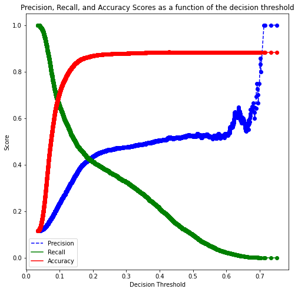

```python
model_gam = LogisticRegression(max_iter=1000).fit(x_transformed, y_train)


model_rf = RandomForestClassifier(n_estimators=500, random_state=4, max_depth=12, max_leaf_nodes=38, max_features=4).fit(X_train, y_train)


model_xgb = xgb.XGBClassifier(objective='binary:logistic', use_label_encoder=False, max_depth=3, n_estimators=300,
                          learning_rate=0.4, subsample=0.4, gamma=1, reg_lambda=2.0, random_state=1).fit(X_train, y_train)


ensemble_model = VotingClassifier(estimators=[
    ('GAM', model_gam),
    ('Random Forest', model_rf),
    ('XGBoost', model_xgb)
], voting='soft')


y_pred_probs_gam = cross_val_predict(model_gam, x_transformed, y_train, cv=10, method='predict_proba')
y_pred_probs_rf = cross_val_predict(model_rf, X_train, y_train, cv=10, method='predict_proba')
y_pred_probs_xgb = cross_val_predict(model_xgb, X_train, y_train, cv=10, method='predict_proba')

avg_pred_probs = (y_pred_probs_gam + y_pred_probs_rf + y_pred_probs_xgb) / 3


p, r, thresholds = precision_recall_curve(y_train, avg_pred_probs[:, 1])
acc = np.ndarray(shape=(len(thresholds),))
i = 0
for th in thresholds:
    y_pred = avg_pred_probs[:, 1] > th
    y_pred = y_pred.astype(int)
    acc[i] = accuracy_score(y_pred, y_train)
    i = i + 1

def plot_precision_recall_vs_threshold(precisions, recalls, thresholds, accuracy):
    plt.figure(figsize=(8, 8))
    plt.title("Precision, Recall, and Accuracy Scores as a function of the decision threshold")
    plt.plot(thresholds, precisions[:-1], "b--", label="Precision")
    plt.plot(thresholds, recalls[:-1], "g-", label="Recall")
    plt.plot(thresholds, accuracy, "r-", label="Accuracy")
    plt.plot(thresholds, precisions[:-1], "o", color='blue')
    plt.plot(thresholds, recalls[:-1], "o", color='green')
    plt.plot(thresholds, accuracy, "o", color='red')
    plt.ylabel("Score")
    plt.xlabel("Decision Threshold")
    plt.legend(loc='best')
    plt.legend()

plot_precision_recall_vs_threshold(p, r, thresholds, acc)
```

```python
data = pd.DataFrame({'Precision': p[:-1], 'Recall': r[:-1], 'Threshold': thresholds, 'Accuracy': acc})

filtered_data = data[data['Recall'] >= 0.65]

sorted_data = filtered_data.sort_values(by='Accuracy', ascending=False)

sorted_data.head(15)
```

|  | Precision | Recall | Threshold | Accuracy |
| --- | --- | --- | --- | --- |
| 18267 | 0.237324 | 0.650097 | 0.100779 | 0.714000 |
| 18266 | 0.237303 | 0.650097 | 0.100777 | 0.714000 |
| 18265 | 0.237261 | 0.650097 | 0.100773 | 0.713971 |
| 18264 | 0.237240 | 0.650097 | 0.100772 | 0.713914 |
| 18263 | 0.237219 | 0.650097 | 0.100769 | 0.713886 |
| 18262 | 0.237177 | 0.650097 | 0.100761 | 0.713857 |
| 18261 | 0.237156 | 0.650097 | 0.100755 | 0.713800 |
| 18260 | 0.237134 | 0.650097 | 0.100753 | 0.713771 |
| 18259 | 0.237092 | 0.650097 | 0.100750 | 0.713743 |
| 18258 | 0.237071 | 0.650097 | 0.100733 | 0.713686 |
| 18257 | 0.237050 | 0.650097 | 0.100733 | 0.713657 |
| 18256 | 0.237029 | 0.650097 | 0.100731 | 0.713629 |
| 18255 | 0.237008 | 0.650097 | 0.100724 | 0.713600 |
| 18254 | 0.236987 | 0.650097 | 0.100721 | 0.713571 |
| 18253 | 0.236966 | 0.650097 | 0.100715 | 0.713543 |

```python
threshold = 0.100779


ensemble_model = VotingClassifier(estimators=[
    ('GAM', model_gam),
    ('Random Forest', model_rf),
    ('XGBoost', model_xgb)
], voting='soft')


ensemble_model.fit(X_train, y_train)


y_pred_probs_test = ensemble_model.predict_proba(X_test)

y_pred_test = (y_pred_probs_test[:, 1] >= threshold).astype(int)


accuracy_test = accuracy_score(y_test, y_pred_test)
recall_test = recall_score(y_test, y_pred_test)


print("Accuracy on test data: ", accuracy_test)
print("Recall on test data: ", recall_test)
```

```
Accuracy on test data:  0.6834279006065349
Recall on test data:  0.6897133220910624
```

### Stacking ensemble - Logistic regression

Develop and tune a stacking ensemble based on them models *1-3* in [E.3.2](https://nustat.github.io/STAT303-3-class-notes/Assignment%20E.html#voting-ensemble---hard-voting) with logistic regression as the metamodel. Tune the hyperparameter `C` and the decision threshold probability to maximize accuracy for a recall of at least 65%.

Report the accuracy and recall on test data for the ensemble.

*(8 points - 3 points for tuning ‘C’, 3 points for tuning the decision threshold probability, 2 points for reporting accuracy and recall on test data)*

```python
model_gam = LogisticRegression(max_iter=1000).fit(x_transformed, y_train)
model_rf = RandomForestClassifier(n_estimators=500, random_state=4, max_depth=12, max_leaf_nodes=38, max_features=4).fit(X_train, y_train)
model_xgb = xgb.XGBClassifier(objective='binary:logistic', use_label_encoder=False, max_depth=3, n_estimators=300, learning_rate=0.4, subsample=0.4, gamma=1, reg_lambda=2.0, random_state=1).fit(X_train, y_train)

preds_gam_train = model_gam.predict_proba(x_transformed)[:, 1]
preds_rf_train = model_rf.predict_proba(X_train)[:, 1]
preds_xgb_train = model_xgb.predict_proba(X_train)[:, 1]

meta_features_train = np.column_stack((preds_gam_train, preds_rf_train, preds_xgb_train))


best_c = None
best_accuracy = 0.0
best_recall = 0.0

for c_val in 10**np.linspace(-2.5, 2):
    metamodel = LogisticRegression(random_state=1, max_iter=1000, C=c_val)
    scoring = ['accuracy', 'recall']
    scores = cross_validate(metamodel, meta_features_train, y_train, cv=5, scoring=scoring)

    mean_accuracy = np.mean(scores['test_accuracy'])
    mean_recall = np.mean(scores['test_recall'])

    if mean_recall > best_recall and mean_accuracy > best_accuracy:
        best_accuracy = mean_accuracy
        best_recall = mean_recall
        best_c = c_val

print("Best C value:", best_c)
print("Best Accuracy:", best_accuracy)
print("Best Recall:", best_recall)
```

```
Best C value: 0.9540954763499944
Best Accuracy: 0.8947428571428573
Best Recall: 0.24269005674222394
```

```python
metamodel = LogisticRegression(max_iter=1000, C=0.9540954763499944)
metamodel.fit(meta_features_train, y_train)


preds_meta = metamodel.predict_proba(meta_features_train)[:, 1]

best_threshold = None
best_accuracy = 0.0
best_recall = 0.0

for threshold in np.linspace(0, 1, 101):

    y_pred = (preds_meta >= threshold).astype(int)

    accuracy = accuracy_score(y_train, y_pred)
    recall = recall_score(y_train, y_pred)

    if recall >= 0.65 and accuracy > best_accuracy:
        best_accuracy = accuracy
        best_recall = recall
        best_threshold = threshold

print("Best Threshold:", best_threshold)
print("Best Accuracy:", best_accuracy)
print("Best Recall:", best_recall)
```

```
Best Threshold: 0.08
Best Accuracy: 0.7050571428571428
Best Recall: 0.702485380116959
```

```python
preds_gam_test = model_gam.predict_proba(x_test_transformed)[:, 1]
preds_rf_test = model_rf.predict_proba(X_test)[:, 1]
preds_xgb_test = model_xgb.predict_proba(X_test)[:, 1]
metamodel_test_X = np.column_stack((preds_gam_test, preds_rf_test, preds_xgb_test))
```

```python
threshold = 0.08

metamodel = LogisticRegression(max_iter=1000, C=0.9540954763499944)
metamodel.fit(meta_features_train, y_train)


y_pred_probs_test = metamodel.predict_proba(metamodel_test_X)

y_pred_test = (y_pred_probs_test[:, 1] >= threshold).astype(int)


accuracy_test = accuracy_score(y_test, y_pred_test)
recall_test = recall_score(y_test, y_pred_test)


print("Accuracy on test data: ", accuracy_test)
print("Recall on test data: ", recall_test)
```

```
Accuracy on test data:  0.6973195069458031
Recall on test data:  0.6795952782462057
```

### Stacking ensemble - Random forest

Develop and tune a stacking ensemble based on them models *1-3* in [E.3.2](https://nustat.github.io/STAT303-3-class-notes/Assignment%20E.html#voting-ensemble---hard-voting) with random forest as the metamodel. Tune the hyperparameter `max_features` to maximize accuracy for a recall of at least 65%.

Report the accuracy and recall on test data for the ensemble.

*(8 points - 3 points for tuning ‘max_features’, 3 points for tuning the decision threshold probability, 2 points for reporting accuracy and recall on test data)*

```python
model_gam = LogisticRegression(max_iter=1000).fit(x_transformed, y_train)
model_rf = RandomForestClassifier(n_estimators=500, random_state=4, max_depth=12, max_leaf_nodes=38, max_features=4).fit(X_train, y_train)
model_xgb = xgb.XGBClassifier(objective='binary:logistic', use_label_encoder=False, max_depth=3, n_estimators=300, learning_rate=0.4, subsample=0.4, gamma=1, reg_lambda=2.0, random_state=1).fit(X_train, y_train)

preds_gam_train = model_gam.predict_proba(x_transformed)[:, 1]
preds_rf_train = model_rf.predict_proba(X_train)[:, 1]
preds_xgb_train = model_xgb.predict_proba(X_train)[:, 1]

meta_features_train = np.column_stack((preds_gam_train, preds_rf_train, preds_xgb_train))

params = {'max_features': list(range(1,4))}

cv = KFold(n_splits=5,shuffle=True,random_state=1)
rf_model = GridSearchCV(RandomForestClassifier(random_state=1, n_jobs=-1),
                                      param_grid =params, cv=cv, n_jobs=-1, verbose=1,
                                      scoring=['accuracy', 'recall'], refit='recall')
rf_model.fit(meta_features_train, y_train)

best_params = rf_model.best_params_
results_df = pd.DataFrame(rf_model.cv_results_)
```

```
Fitting 5 folds for each of 3 candidates, totalling 15 fits
```

```python
best_params
```

```
{'max_features': 3}
```

```python
metamodel = RandomForestClassifier(random_state=1, n_jobs=-1, max_features=3)
metamodel.fit(meta_features_train, y_train)

preds_meta = metamodel.predict_proba(meta_features_train)[:, 1]

thresholds = np.arange(0.09,0.1,0.001)

results = []

for threshold in thresholds:
    y_pred = (preds_meta >= threshold).astype(int)
    accuracy = accuracy_score(y_train, y_pred)
    recall = recall_score(y_train, y_pred)

    if recall >= 0.65:
        results.append((threshold, accuracy, recall))

# Sort the results based on accuracy in descending order
results.sort(key=lambda x: x[1], reverse=True)

# Print the sorted results
for threshold, accuracy, recall in results:
    print("Threshold:", threshold)
    print("Accuracy:", accuracy)
    print("Recall:", recall)
```

```
Threshold: 0.1
Accuracy: 0.7868571428571428
Recall: 0.9566276803118908
Threshold: 0.099
Accuracy: 0.7850285714285714
Recall: 0.9583333333333334
Threshold: 0.098
Accuracy: 0.7839428571428572
Recall: 0.959307992202729
Threshold: 0.097
Accuracy: 0.7826
Recall: 0.9605263157894737
Threshold: 0.096
Accuracy: 0.7800285714285714
Recall: 0.9627192982456141
Threshold: 0.095
Accuracy: 0.7782571428571429
Recall: 0.9641812865497076
Threshold: 0.094
Accuracy: 0.7772857142857142
Recall: 0.9649122807017544
Threshold: 0.093
Accuracy: 0.7760857142857143
Recall: 0.9658869395711501
Threshold: 0.092
Accuracy: 0.7751714285714286
Recall: 0.966374269005848
Threshold: 0.091
Accuracy: 0.7736285714285714
Recall: 0.9675925925925926
Threshold: 0.09
Accuracy: 0.7721714285714286
Recall: 0.9678362573099415
```

```
(0.05, 0.1)
```

[figure not shown]

```python
thresholds = [result[0] for result in results]
accuracies = [result[1] for result in results]
recalls = [result[2] for result in results]

plt.plot(thresholds, accuracies, label='Accuracy')

plt.plot(thresholds, recalls, label='Recall')

plt.xlabel('Threshold')
plt.ylabel('Score')
plt.title('Recall and Accuracy vs Threshold')
plt.legend()
plt.xlim(0.05,0.10)
```

```python
threshold = 0.093

metamodel = RandomForestClassifier(random_state=1, n_jobs=-1, max_features=3)
metamodel.fit(meta_features_train, y_train)


y_pred_probs_test = metamodel.predict_proba(metamodel_test_X)

y_pred_test = (y_pred_probs_test[:, 1] >= threshold).astype(int)


accuracy_test = accuracy_score(y_test, y_pred_test)
recall_test = recall_score(y_test, y_pred_test)


print("Accuracy on test data: ", accuracy_test)
print("Recall on test data: ", recall_test)
```

```
Accuracy on test data:  0.6484054001173939
Recall on test data:  0.6526138279932546
```